# Czynniki wpływające na czas rozwiązywania zadań z matematyki PISA 2015 - etap II

# 5.Wizualizacja modelu

Zależność pozycji zadania od czasu jego rozwiązywania.

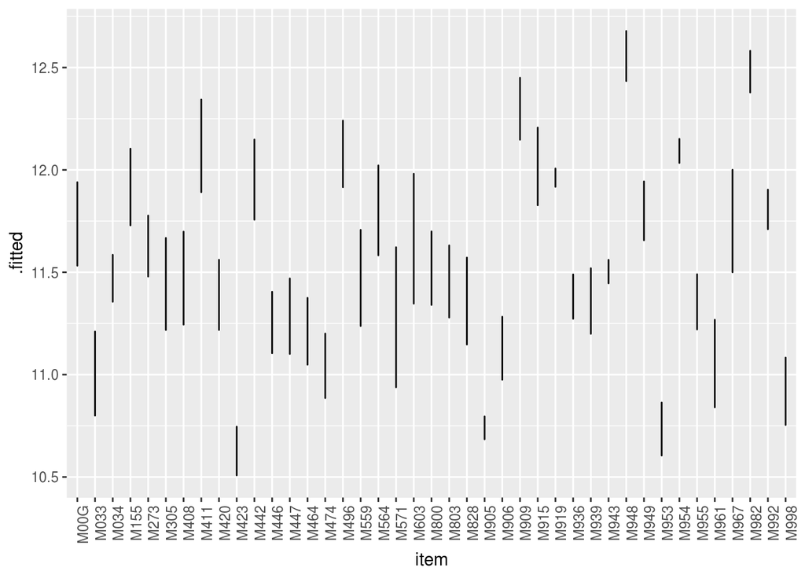

```r
dane_wykres2 <- augment(model_liniowy3)
g <- ggplot(dane_wykres2, aes(item, .fitted)) +geom_line()
g <- g + theme(legend.position="none", axis.text.x = element_text(angle = 90, hjust = 1))
g
```

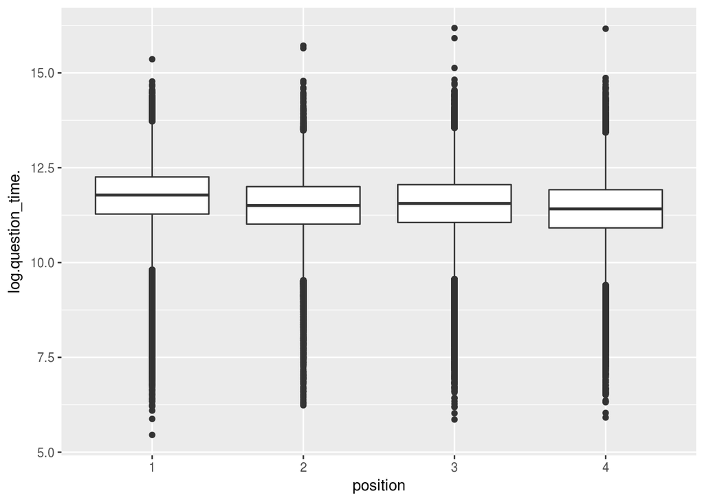

```r
ggplot(dane_wykres2, aes(position, log.question_time.)) + geom_boxplot()
```

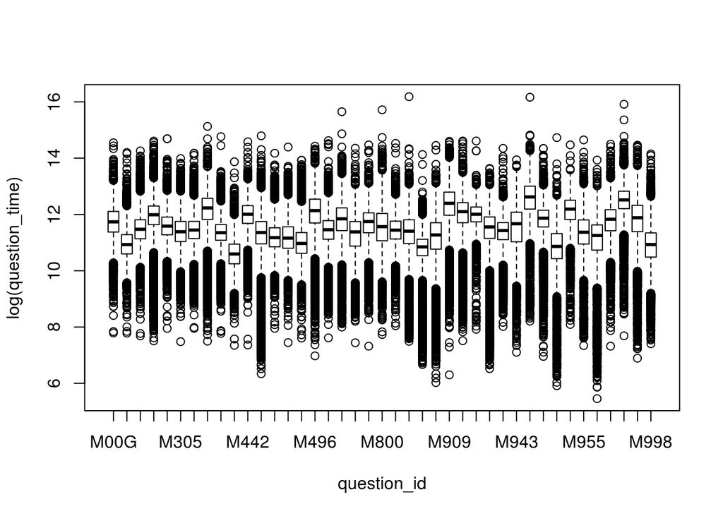

```r
boxplot(log(question_time)~item,data=atsm2, xlab="question_id", ylab="log(question_time)")
```

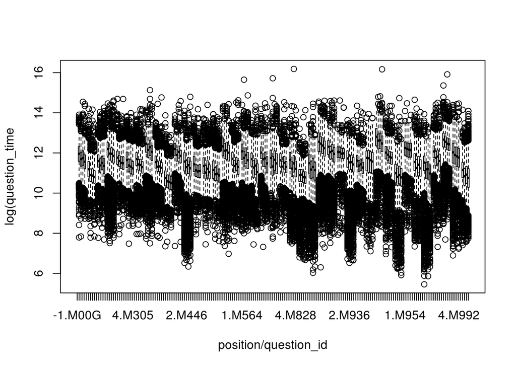

```r
boxplot(log(question_time)~position/item,data=atsm2, xlab="position/question_id", ylab="log(question_time")
```

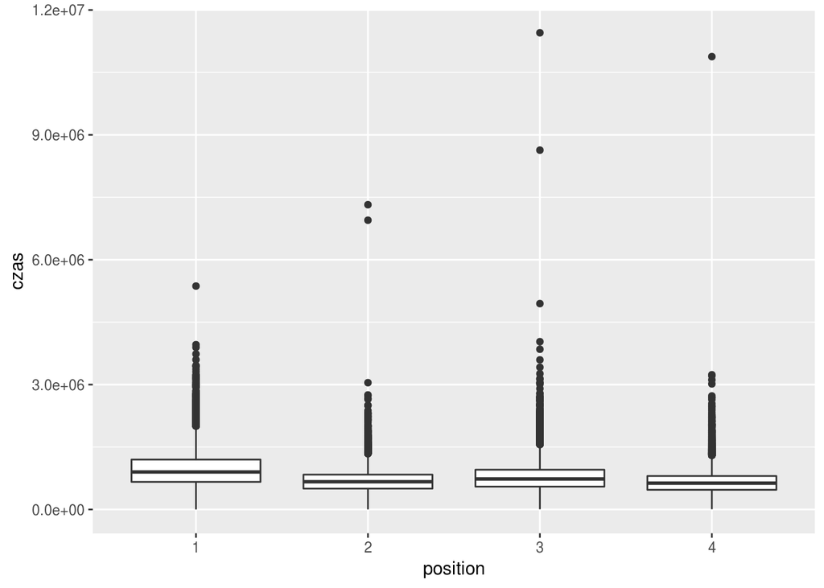

```r
data_2 <- atsm2 %>% group_by(position,CNTSTUID) %>% summarize(sum(question_time))
colnames(data_2)[3]<- "czas"

ggplot(data_2, aes(position, czas)) +geom_boxplot()
```

# 6.Podsumowanie

Szeroko zakrojona diagnostyka modelu wykazała, że wybrany przez nas model zbudowany na zmiennych: position (pozycja w kwestionariuszu) oraz item (zadanie) w etapie pierwszym niestety nie odzwierciedla danych idealnie. Można zauważyć jednak, że występuje zależność pomiędzy czasem wykonywania zadań, a pozycją w kwestionariuszu (zadanie na ostatniej pozycji jest rozwiązywane najkrócej). Nie są to jednak duże róźnice. Tak więc konieczna byłaby konstrukacja i testowanie kolejnych modeli.